# Resolução da Lista de Exercícios 2

Prof. Washington Santos da Silva

```r
library(here)
library(tidyverse)
library(FactoMineR)
library(factoextra)
```

## Questão 1

### 1.1

```r
path_happy <- here::here("data_raw", "world-happiness-report-2021.csv")
HAPPY <- read.csv(path_happy, check.names = FALSE)
```

verificando os dados importados:

```r
dplyr::glimpse(HAPPY)
```

```
Rows: 149
Columns: 20
$ `Country name`                               <chr> "Finland", "Denmark", "…
$ `Regional indicator`                         <chr> "Western Europe", "West…
$ `Ladder score`                               <dbl> 7.842, 7.620, 7.571, 7.…
$ `Standard error of ladder score`             <dbl> 0.032, 0.035, 0.036, 0.…
$ upperwhisker                                 <dbl> 7.904, 7.687, 7.643, 7.…
$ lowerwhisker                                 <dbl> 7.780, 7.552, 7.500, 7.…
$ `Logged GDP per capita`                      <dbl> 10.775, 10.933, 11.117,…
$ `Social support`                             <dbl> 0.954, 0.954, 0.942, 0.…
$ `Healthy life expectancy`                    <dbl> 72.000, 72.700, 74.400,…
$ `Freedom to make life choices`               <dbl> 0.949, 0.946, 0.919, 0.…
$ Generosity                                   <dbl> -0.098, 0.030, 0.025, 0…
$ `Perceptions of corruption`                  <dbl> 0.186, 0.179, 0.292, 0.…
$ `Ladder score in Dystopia`                   <dbl> 2.43, 2.43, 2.43, 2.43,…
$ `Explained by: Log GDP per capita`           <dbl> 1.446, 1.502, 1.566, 1.…
$ `Explained by: Social support`               <dbl> 1.106, 1.108, 1.079, 1.…
$ `Explained by: Healthy life expectancy`      <dbl> 0.741, 0.763, 0.816, 0.…
$ `Explained by: Freedom to make life choices` <dbl> 0.691, 0.686, 0.653, 0.…
$ `Explained by: Generosity`                   <dbl> 0.124, 0.208, 0.204, 0.…
$ `Explained by: Perceptions of corruption`    <dbl> 0.481, 0.485, 0.413, 0.…
$ `Dystopia + residual`                        <dbl> 3.253, 2.868, 2.839, 2.…
```

### 1.2

```r
happy <- HAPPY[ ,8:12]
names(happy)
```

```
[1] "Social support"               "Healthy life expectancy"
[3] "Freedom to make life choices" "Generosity"
[5] "Perceptions of corruption"
```

### 1.3

```r
rownames(happy) <- HAPPY[ ,1]
```

verificando os dados:

```r
head(happy)
```

|  | Social support | Healthy life expectancy | Freedom to make life choices | Generosity | Perceptions of corruption |
| --- | --- | --- | --- | --- | --- |
| Finland | 0.954 | 72.0 | 0.949 | -0.098 | 0.186 |
| Denmark | 0.954 | 72.7 | 0.946 | 0.030 | 0.179 |
| Switzerland | 0.942 | 74.4 | 0.919 | 0.025 | 0.292 |
| Iceland | 0.983 | 73.0 | 0.955 | 0.160 | 0.673 |
| Netherlands | 0.942 | 72.4 | 0.913 | 0.175 | 0.338 |
| Norway | 0.954 | 73.3 | 0.960 | 0.093 | 0.270 |

## Questão 2

### 2.1

```r
happy_pca <- FactoMineR::PCA(happy, ncp = 5, graph = FALSE)
```

### 2.2

```r
summary(happy_pca)
```

```
Call:
FactoMineR::PCA(X = happy, ncp = 5, graph = FALSE)


Eigenvalues
                       Dim.1   Dim.2   Dim.3   Dim.4   Dim.5
Variance               2.348   1.226   0.703   0.478   0.245
% of var.             46.965  24.513  14.050   9.566   4.906
Cumulative % of var.  46.965  71.477  85.528  95.094 100.000

Individuals (the 10 first)
                                 Dist    Dim.1    ctr   cos2    Dim.2    ctr
Finland                      |  3.741 |  3.092  2.732  0.683 |  0.576  0.182
Denmark                      |  3.765 |  3.148  2.832  0.699 |  1.241  0.843
Switzerland                  |  3.236 |  2.874  2.360  0.789 |  0.862  0.407
Iceland                      |  2.668 |  2.291  1.501  0.738 |  0.749  0.307
Netherlands                  |  3.155 |  2.578  1.899  0.667 |  1.613  1.425
Norway                       |  3.507 |  3.064  2.683  0.763 |  1.379  1.041
Sweden                       |  3.497 |  2.924  2.444  0.699 |  1.451  1.152
Luxembourg                   |  2.579 |  2.312  1.527  0.803 |  0.450  0.111
New Zealand                  |  3.573 |  2.966  2.514  0.689 |  1.600  1.403
Austria                      |  2.391 |  2.292  1.501  0.919 |  0.555  0.168
                               cos2    Dim.3    ctr   cos2
Finland                       0.024 | -1.897  3.437  0.257 |
Denmark                       0.109 | -1.546  2.284  0.169 |
Switzerland                   0.071 | -1.152  1.267  0.127 |
Iceland                       0.079 |  1.130  1.221  0.180 |
Netherlands                   0.261 | -0.508  0.246  0.026 |
Norway                        0.155 | -0.929  0.824  0.070 |
Sweden                        0.172 | -1.187  1.345  0.115 |
Luxembourg                    0.030 | -1.046  1.046  0.165 |
New Zealand                   0.201 | -1.005  0.965  0.079 |
Austria                       0.054 | -0.314  0.094  0.017 |

Variables
                                Dim.1    ctr   cos2    Dim.2    ctr   cos2
Social support               |  0.825 28.969  0.680 | -0.295  7.100  0.087 |
Healthy life expectancy      |  0.862 31.677  0.744 | -0.269  5.882  0.072 |
Freedom to make life choices |  0.764 24.832  0.583 |  0.285  6.635  0.081 |
Generosity                   | -0.007  0.002  0.000 |  0.884 63.813  0.782 |
Perceptions of corruption    | -0.584 14.519  0.341 | -0.451 16.570  0.203 |
                              Dim.3    ctr   cos2
Social support                0.303 13.039  0.092 |
Healthy life expectancy       0.002  0.001  0.000 |
Freedom to make life choices  0.178  4.508  0.032 |
Generosity                    0.380 20.580  0.145 |
Perceptions of corruption     0.659 61.872  0.435 |
```

### 2.3

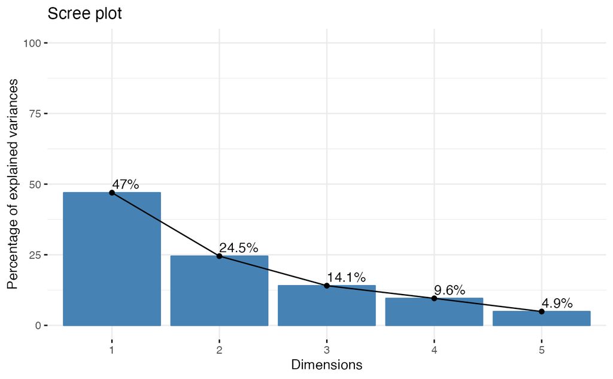

```r
factoextra::fviz_screeplot(
  happy_pca,
  choice = "variance",
  addlabels = TRUE,
  ylim = c(0, 100)
)
```

## Questão 3

### 3.1

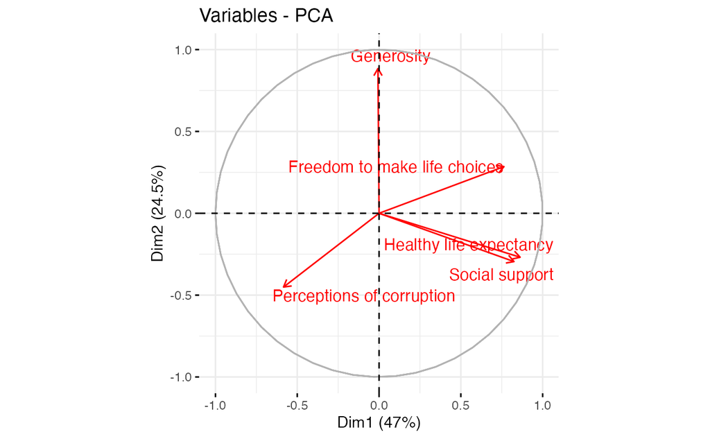

```r
factoextra::fviz_pca_var(happy_pca, col.var = "red", repel = TRUE)
```

## Questão 4

### 4.1

Em um R Notebook, é possível visualizar adequadamente o gráfico clicando no botão acima da figura que a expande.

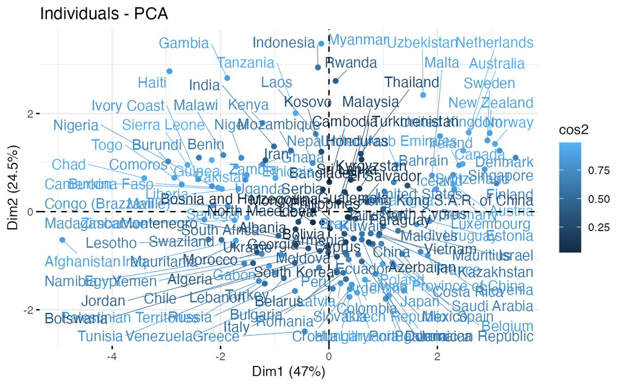

```r
factoextra::fviz_pca_ind(happy_pca,
                         col.ind = "cos2",
                         repel = TRUE,
                         label = "ind")
```

### 4.2

- Bolívia
- Paraguai
- Líbia
- El Salvador
- Chipre

Note que esses países estão próximos da origem dos eixos e seus nomes possuem uma tom bastante escuro, conforme a escala do `cos2` exibida.

## Questão 5

### 5.1

Da mesma forma, é importante destacar que em um R Notebook, é possível visualizar adequadamente o biplot clicando no botão acima da figura que a expande.

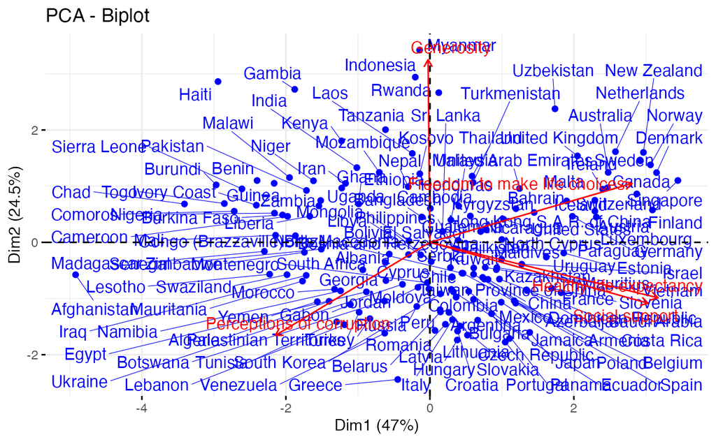

```r
factoextra::fviz_pca_biplot(
  happy_pca,
  label = "all",
  col.var = "red",
  col.ind = "blue",
  repel = TRUE
)
```

## Questão 6

Os vetores de cargas dos dois primeiros componentes principais são:

PC1 = 0.825(`Social`) + 0.862(`Health`) + 0.764(`Freedom`) - 0.007(`Generosity`) - 0.584(`Corruption`)

PC2 = -0.295(`Social`) - 0.269(`Health`) + 0.285(`Freedom`) + 0.884(`Generosity`) - 0.451(`Corruption`)

Embora seja a interpretação espacial com respeito às direções das variáveis que seja mais importante, é muitas vezes possível, como neste caso, interpretar as próprias direções dos componentes (ou seja, as dimensões, também chamadas de eixos principais).

O primeiro componente é claramente uma escala de negativa para positiva em termos das quatro variáveis à exceção de `Generosity`, enquanto `Generosity` é o principal motor da segunda dimensão, opondo-se principalmente a `Corruption`.

Por exemplo, olhando para o posições do Reino Unido, Malta, Alemanha e França no biplot, eles estão todos na mesma posição no primeiro componente, mas dispersos verticalmente em relação ao segundo. Assim, eles têm a mesma posição em seu “tamanho” geral na primeira dimensão, mas a composição de suas classificações, sua “forma”, é diferente entre os quatro países.

O Reino Unido tende a ser superior à média em `Generosity` e abaixo da média em `Corruption`, e também inferior em `Life` e `Social`, mas ainda assim mais alto do que a média. Por outro lado, a França é superior nas três variáveis que apontam para baixo (`Health`, `Life` and `Corruption`) e inferior do que a média em `Generosity`.